```r
library(h2o)
h2o.init(nthreads = -1,  # Liczba wątków: -1 oznacza użycie wszystkich dostępnych rdzeni
         max_mem_size = "8G") # Maksymalna ilość pamięci przydzielonej dla H2O
```

```
##
## H2O is not running yet, starting it now...
##
## Note:  In case of errors look at the following log files:
##     C:\Users\grzet\AppData\Local\Temp\RtmpSoJb2J\file2ed43ba96c34/h2o_grzet_started_from_r.out
##     C:\Users\grzet\AppData\Local\Temp\RtmpSoJb2J\file2ed424fc651f/h2o_grzet_started_from_r.err
##
##
## Starting H2O JVM and connecting:  Connection successful!
##
## R is connected to the H2O cluster:
##     H2O cluster uptime:         4 seconds 431 milliseconds
##     H2O cluster timezone:       Europe/Belgrade
##     H2O data parsing timezone:  UTC
##     H2O cluster version:        3.44.0.3
##     H2O cluster version age:    1 year, 5 months and 14 days
##     H2O cluster name:           H2O_started_from_R_grzet_vif188
##     H2O cluster total nodes:    1
##     H2O cluster total memory:   7.10 GB
##     H2O cluster total cores:    16
##     H2O cluster allowed cores:  16
##     H2O cluster healthy:        TRUE
##     H2O Connection ip:          localhost
##     H2O Connection port:        54321
##     H2O Connection proxy:       NA
##     H2O Internal Security:      FALSE
##     R Version:                  R version 4.3.3 (2024-02-29 ucrt)
```

```r
loan_csv <- "https://raw.githubusercontent.com/h2oai/app-consumer-loan/master/data/loan.csv"
data <- h2o.importFile(loan_csv)
```

```
##   |                                                                              |                                                                      |   0%  |                                                                              |==                                                       …
```

```r
data
```

```
##   loan_amnt      term int_rate emp_length home_ownership annual_inc
## 1      5000 36 months    10.65         10           RENT      24000
## 2      2500 60 months    15.27          0           RENT      30000
## 3      2400 36 months    15.96         10           RENT      12252
## 4     10000 36 months    13.49         10           RENT      49200
## 5      5000 36 months     7.90          3           RENT      36000
## 6      3000 36 months    18.64          9           RENT      48000
##          purpose addr_state   dti delinq_2yrs revol_util total_acc bad_loan
## 1    credit_card         AZ 27.65           0       83.7         9        0
## 2            car         GA  1.00           0        9.4         4        1
## 3 small_business         IL  8.72           0       98.5        10        0
## 4          other         CA 20.00           0       21.0        37        0
## 5        wedding         AZ 11.20           0       28.3        12        0
## 6            car         CA  5.35           0       87.5         4        0
##   longest_credit_length verification_status
## 1                    26            verified
## 2                    12            verified
## 3                    10        not verified
## 4                    15            verified
## 5                     7            verified
## 6                     4            verified
##
## [163987 rows x 15 columns]
```

```r
data$bad_loan <- as.factor(data$bad_loan)  # kodujemy zmienną binarną jako faktor
h2o.levels(data$bad_loan)  # opcjonalnie: sprawdzamy poziomy faktora ('0' i '1')
```

```
## [1] "0" "1"
```

```r
splits <- h2o.splitFrame(data = data,
                         ratios = c(0.7, 0.15),  # podział: 70%, 15%, 15%
                         seed = 1)
train <- splits[[1]]
valid <- splits[[2]]
test <- splits[[3]]
```

```r
nrow(train)
```

```
## [1] 114908
```

```r
nrow(valid)
```

```
## [1] 24498
```

```r
nrow(test)
```

```
## [1] 24581
```

```r
y <- "bad_loan"
x <- setdiff(names(data), c(y))
print(x)
```

```
##  [1] "loan_amnt"             "term"                  "int_rate"
##  [4] "emp_length"            "home_ownership"        "annual_inc"
##  [7] "purpose"               "addr_state"            "dti"
## [10] "delinq_2yrs"           "revol_util"            "total_acc"
## [13] "longest_credit_length" "verification_status"
```

### Gradient Boosting Machine

Gradient Boosting Machine działa na drzewach decyzyjnych, które są prostymi modelami decyzyjnymi, działającymi jak zestaw pytań (np. “Czy wiek jest większy niż 30 lat?”). Jednak pojedyncze drzewo jest słabe, dlatego GBM buduje wiele drzew, jedno po drugim, w taki sposób, że każde kolejne drzewo poprawia błędy poprzednich. Algorytm stara się zoptymalizować błędy (funkcję straty) poprzez dodawanie nowych drzew, które “skupiają się” na przypadkach, które zostały źle sklasyfikowane przez poprzednie drzewa. W ten sposób GBM stopniowo tworzy bardzo mocny model.

To lista, która zawiera parametry dla modelu Gradient Boosting Machine (GBM): - **`learn_rate`**: wektor z wartościami `c(0.01, 0.1)`, które określają szybkość uczenia modelu. - **`max_depth`**: wektor `c(3, 5, 9)`, który ustala maksymalną głębokość drzewa decyzyjnego. - **`sample_rate`**: wektor `c(0.8, 1.0)`, który ustala proporcję próbek używanych w treningu. - **`col_sample_rate`**: wektor `c(0.2, 0.5, 1.0)`, który ustala procent cech wybieranych w każdym drzewie.

```r
gbm_params1 <- list(learn_rate = c(0.01, 0.1),
                    max_depth = c(3, 5, 9),
                    sample_rate = c(0.8, 1.0),
                    col_sample_rate = c(0.2, 0.5, 1.0))
```

To lista, która określa kryteria poszukiwania najlepszych parametrów dla modelu: - **`strategy`**: ustawione na `"RandomDiscrete"`, co oznacza, że poszukiwania są realizowane losowo, w sposób dyskretny. - **`max_runtime_secs`**: ustawione na `120`, co oznacza, że proces poszukiwania może trwać maksymalnie 120 sekund.

```r
search_criteria <- list(strategy = "RandomDiscrete",
                        max_runtime_secs = 120)
```

Zmienna, która tworzy nową siatkę parametrów dla modelu GBM. Składa się z: - **`x = x, y = y`**: Zmienne objaśniające (`x`) oraz zmienna celu (`y`). - **`grid_id`**: identyfikator tej siatki, ustawiony na `"gbm_grid1"`. - **`training_frame`**: ramka danych do treningu, zdefiniowana jako `train`. - **`validation_frame`**: ramka danych do walidacji, zdefiniowana jako `valid`. - **`ntrees`**: liczba drzew w modelu, ustawiona na `100`. - **`seed`**: ziarno generatora liczb losowych, ustawione na `1`. - **`hyper_params`**: odnosi się do zmiennych parametrów hyper, czyli `gbm_params1`. - **`search_criteria`**: odnosi się do kryteriów wyszukiwania, czyli `search_criteria`.

```r
# Tworzymy nową siatkę z tymi samymi danymi
gbm_grid1 <- h2o.grid("gbm", x = x, y = y,
                         grid_id = "gbm_grid1",  # Nowa siatka z nowym ID
                         training_frame = train,
                         validation_frame = valid,
                         ntrees = 100,
                         seed = 1,
                         hyper_params = gbm_params1,
                         search_criteria = search_criteria)
```

```
##   |                                                                              |                                                                      |   0%  |                                                                              |=                                                        …
```

Zmienna, która zawiera wyniki uzyskane po przeprowadzeniu poszukiwań najlepszych parametrów. Składa się z: - **`h2o.getGrid`**: funkcja służąca do pobrania wyników grid search dla określonego `grid_id` (tutaj `"gbm_grid1"`). - **`sort_by`**: kryterium sortowania wyników, ustawione na `"auc"` (area under curve), czyli miara jakości modelu. - **`decreasing`**: ustawione na `TRUE`, co oznacza, że wyniki będą posortowane malejąco.

```r
gbm_gridperf1 <- h2o.getGrid(grid_id = "gbm_grid1",
                             sort_by = "auc",
                             decreasing = TRUE)
print(gbm_gridperf1)
```

```
## H2O Grid Details
## ================
##
## Grid ID: gbm_grid1
## Used hyper parameters:
##   -  col_sample_rate
##   -  learn_rate
##   -  max_depth
##   -  sample_rate
## Number of models: 28
## Number of failed models: 0
##
## Hyper-Parameter Search Summary: ordered by decreasing auc
##   col_sample_rate learn_rate max_depth sample_rate          model_ids     auc
## 1         1.00000    0.10000   5.00000     0.80000  gbm_grid1_model_3 0.71077
## 2         0.50000    0.10000   5.00000     1.00000 gbm_grid1_model_12 0.71066
## 3         0.50000    0.10000   5.00000     0.80000  gbm_grid1_model_1 0.70999
## 4         0.50000    0.10000   3.00000     1.00000  gbm_grid1_model_7 0.70974
## 5         1.00000    0.10000   3.00000     1.00000 gbm_grid1_model_19 0.70967
##
## ---
##    col_sample_rate learn_rate max_depth sample_rate          model_ids     auc
## 23         1.00000    0.01000   5.00000     1.00000 gbm_grid1_model_23 0.69840
## 24         1.00000    0.01000   9.00000     1.00000 gbm_grid1_model_21 0.69839
## 25         1.00000    0.10000   9.00000     1.00000 gbm_grid1_model_25 0.69746
## 26         0.50000    0.01000   3.00000     0.80000 gbm_grid1_model_26 0.69260
## 27         1.00000    0.01000   3.00000     0.80000 gbm_grid1_model_18 0.69006
## 28         1.00000    0.01000   3.00000     1.00000  gbm_grid1_model_5 0.69000
```

```r
gbm_params2 <- list(learn_rate = seq(0.01, 0.1, 0.01),
                    max_depth = seq(2, 10, 1),
                    sample_rate = seq(0.5, 1.0, 0.1),
                    col_sample_rate = seq(0.1, 1.0, 0.1))
search_criteria2 <- list(strategy = "RandomDiscrete",
                         max_models = 36)
```

```r
gbm_grid2 <- h2o.grid("gbm", x = x, y = y,
                      grid_id = "gbm_grid2",
                      training_frame = train,
                      validation_frame = valid,
                      ntrees = 100,
                      seed = 1,
                      hyper_params = gbm_params2,
                      search_criteria = search_criteria2)
```

```
##   |                                                                              |                                                                      |   0%  |                                                                              |=========================================================…
```

```r
gbm_gridperf2 <- h2o.getGrid(grid_id = "gbm_grid2",
                             sort_by = "auc",
                             decreasing = TRUE)
print(gbm_gridperf2)
```

```
## H2O Grid Details
## ================
##
## Grid ID: gbm_grid2
## Used hyper parameters:
##   -  col_sample_rate
##   -  learn_rate
##   -  max_depth
##   -  sample_rate
## Number of models: 36
## Number of failed models: 0
##
## Hyper-Parameter Search Summary: ordered by decreasing auc
##   col_sample_rate learn_rate max_depth sample_rate          model_ids     auc
## 1         0.40000    0.06000   6.00000     1.00000 gbm_grid2_model_25 0.70971
## 2         0.60000    0.07000   4.00000     0.90000 gbm_grid2_model_19 0.70964
## 3         0.90000    0.06000   4.00000     0.60000 gbm_grid2_model_32 0.70957
## 4         0.60000    0.09000   6.00000     0.70000 gbm_grid2_model_28 0.70946
## 5         0.20000    0.09000   5.00000     0.90000 gbm_grid2_model_10 0.70933
##
## ---
##    col_sample_rate learn_rate max_depth sample_rate          model_ids     auc
## 31         0.90000    0.06000  10.00000     0.70000 gbm_grid2_model_22 0.70169
## 32         0.70000    0.04000   2.00000     0.80000  gbm_grid2_model_8 0.69912
## 33         0.70000    0.10000  10.00000     0.90000 gbm_grid2_model_12 0.69870
## 34         0.70000    0.10000   9.00000     0.60000  gbm_grid2_model_7 0.69645
## 35         0.90000    0.01000   2.00000     0.90000  gbm_grid2_model_3 0.68439
## 36         0.80000    0.10000  10.00000     0.50000  gbm_grid2_model_6 0.68196
```

```r
gbm_params <- list(learn_rate = seq(0.1, 0.3, 0.01),  # zaktualizowane
                   max_depth = seq(2, 10, 1),
                   sample_rate = seq(0.9, 1.0, 0.05),  # zaktualizowane
                   col_sample_rate = seq(0.1, 1.0, 0.1))
search_criteria <- list(strategy = "RandomDiscrete",
                         max_runtime_secs = 60)  # zaktualizowane


gbm_grid <- h2o.grid("gbm", x = x, y = y,
                      grid_id = "gbm_grid2",
                      training_frame = train,
                      validation_frame = valid,
                      ntrees = 100,
                      seed = 1,
                      hyper_params = gbm_params,
                      search_criteria = search_criteria2)
```

```
##   |                                                                              |                                                                      |   0%  |                                                                              |=========================================================…
```

```r
gbm_gridperf <- h2o.getGrid(grid_id = "gbm_grid2",
                             sort_by = "auc",
                             decreasing = TRUE)
print(gbm_gridperf)
```

```
## H2O Grid Details
## ================
##
## Grid ID: gbm_grid2
## Used hyper parameters:
##   -  col_sample_rate
##   -  learn_rate
##   -  max_depth
##   -  sample_rate
## Number of models: 72
## Number of failed models: 0
##
## Hyper-Parameter Search Summary: ordered by decreasing auc
##   col_sample_rate learn_rate max_depth sample_rate          model_ids     auc
## 1         1.00000    0.17000   3.00000     0.95000 gbm_grid2_model_49 0.71093
## 2         0.80000    0.15000   4.00000     0.90000 gbm_grid2_model_53 0.71092
## 3         0.50000    0.12000   5.00000     0.95000 gbm_grid2_model_43 0.71025
## 4         0.80000    0.10000   5.00000     1.00000 gbm_grid2_model_50 0.70991
## 5         1.00000    0.13000   4.00000     1.00000 gbm_grid2_model_56 0.70988
##
## ---
##    col_sample_rate learn_rate max_depth sample_rate          model_ids     auc
## 67         0.30000    0.16000  10.00000     0.95000 gbm_grid2_model_67 0.68987
## 68         0.50000    0.18000  10.00000     0.95000 gbm_grid2_model_65 0.68731
## 69         0.90000    0.01000   2.00000     0.90000  gbm_grid2_model_3 0.68439
## 70         0.80000    0.10000  10.00000     0.50000  gbm_grid2_model_6 0.68196
## 71         0.50000    0.28000  10.00000     1.00000 gbm_grid2_model_68 0.67897
## 72         0.80000    0.25000  10.00000     1.00000 gbm_grid2_model_51 0.67661
```

```r
best_gbm_model_id <- gbm_gridperf@model_ids[[1]]
best_gbm <- h2o.getModel(best_gbm_model_id)
```

```r
best_gbm_perf <- h2o.performance(model = best_gbm,
                                 newdata = test)
h2o.auc(best_gbm_perf)
```

```
## [1] 0.709823
```

### Deep Learning

Deep Learning działa na podstawie sztucznych sieci neuronowych, które są inspirowane tym, jak działa ludzki mózg. Sieć składa się z warstw neuronów, które analizują dane w sposób stopniowy. Na przykład, jeśli uczymy sieć rozpoznawania obrazów, pierwsza warstwa może wykrywać proste cechy, jak krawędzie, druga bardziej złożone, jak kąty, a trzecia – całe obiekty. Sieci neuronowe “uczą się” na podstawie przykładów, a algorytm stopniowo poprawia się, dostosowując swoje parametry (wagi), by lepiej rozpoznawać wzorce w danych.

Zmienna ta zawiera wektor różnych funkcji aktywacji, które mogą być użyte w modelu Deep Learning. Funkcje aktywacji wpływają na sposób, w jaki sieć neuronowa przetwarza dane wejściowe w swoich warstwach. Dostępne opcje to: - **`"Rectifier"`**: Najczęściej stosowana funkcja aktywacji w sieciach neuronowych (ReLU). - **`"RectifierWithDropout"`**: Wersja funkcji ReLU, która dodatkowo stosuje technikę dropout, aby zapobiec przeuczeniu. - **`"Maxout"`**: Alternatywna funkcja aktywacji, która może pomóc w modelowaniu bardziej złożonych zależności. - **`"MaxoutWithDropout"`**: Wersja Maxout, która również wykorzystuje technikę dropout.

Zmienna zawiera wektor wartości, które mogą być użyte do regularyzacji L1. Regularyzacja L1 dodaje karę do funkcji kosztu modelu, aby zapobiec przeuczeniu, zmieniając wartości wag. Wartości w tym wektorze to: - **`c(0, 0.00001, 0.0001, 0.001, 0.01, 0.1)`**: Wartości regularyzacji L1, gdzie 0 oznacza brak regularyzacji.

Zmienna zawiera wektor wartości, które mogą być użyte do regularyzacji L2. Podobnie jak regularyzacja L1, L2 również przeciwdziała przeuczeniu, ale w inny sposób, nakładając karę na kwadraty wag. Wartości w tym wektorze to: - **`c(0, 0.00001, 0.0001, 0.001, 0.01, 0.1)`**: Wartości regularyzacji L2, podobnie jak w `l1_opt`.

```r
activation_opt <- c("Rectifier", "RectifierWithDropout", "Maxout", "MaxoutWithDropout")
l1_opt <- c(0, 0.00001, 0.0001, 0.001, 0.01, 0.1)
l2_opt <- c(0, 0.00001, 0.0001, 0.001, 0.01, 0.1)
```

Jest to lista, która zawiera hiperparametry, które będą testowane w procesie trenowania modelu. Zawiera następujące elementy: - **`activation`**: Wybór jednej z funkcji aktywacji z wektora `activation_opt`. - **`l1`**: Wybór wartości regularyzacji L1 z wektora `l1_opt`. - **`l2`**: Wybór wartości regularyzacji L2 z wektora `l2_opt`.

```r
hyper_params <- list(activation = activation_opt,
                     l1 = l1_opt,
                     l2 = l2_opt)
```

```r
dl_grid <- h2o.grid("deeplearning", x = x, y = y,
                    grid_id = "dl_grid",
                    training_frame = train,
                    validation_frame = valid,
                    seed = 1,
                    hidden = c(10,10),
                    hyper_params = hyper_params,
                    search_criteria = search_criteria)
```

```
##   |                                                                              |                                                                      |   0%  |                                                                              |==                                                       …
```

Zmienna przechowująca wyniki wyszukiwania najlepszych parametrów w siatce modelu. Obejmuje wyniki grid search z posortowanymi wartościami: - **`h2o.getGrid`**: Funkcja pobierająca wyniki grid search dla podanego `grid_id` (“dl_grid”). - **`sort_by`**: Określa, według jakiej miary wyniki mają być posortowane (w tym przypadku `"auc"`, czyli area under curve). - **`decreasing`**: Określa, czy sortowanie ma odbywać się w porządku malejącym (ustawione na `TRUE`, aby najlepiej oceniane modele były na górze listy).

```r
dl_gridperf <- h2o.getGrid(grid_id = "dl_grid",
                           sort_by = "auc",
                           decreasing = TRUE)
print(dl_gridperf)
```

```
## H2O Grid Details
## ================
##
## Grid ID: dl_grid
## Used hyper parameters:
##   -  activation
##   -  l1
##   -  l2
## Number of models: 48
## Number of failed models: 0
##
## Hyper-Parameter Search Summary: ordered by decreasing auc
##   activation      l1      l2        model_ids     auc
## 1  Rectifier 0.00000 0.00100  dl_grid_model_3 0.70484
## 2  Rectifier 0.00001 0.00100  dl_grid_model_1 0.70473
## 3     Maxout 0.00001 0.00100 dl_grid_model_10 0.70453
## 4     Maxout 0.00000 0.00100 dl_grid_model_31 0.70399
## 5     Maxout 0.00100 0.00010 dl_grid_model_46 0.70341
##
## ---
##              activation      l1      l2        model_ids     auc
## 43 RectifierWithDropout 0.01000 0.10000 dl_grid_model_40 0.50000
## 44    MaxoutWithDropout 0.10000 0.01000  dl_grid_model_6 0.50000
## 45            Rectifier 0.10000 0.00000 dl_grid_model_13 0.49997
## 46            Rectifier 0.10000 0.00001 dl_grid_model_29 0.49995
## 47    MaxoutWithDropout 0.01000 0.10000 dl_grid_model_39 0.49869
## 48               Maxout 0.10000 0.00100 dl_grid_model_24 0.49709
```

Zmienna zawierająca identyfikator najlepszego modelu, wybranego na podstawie wyników `dl_gridperf`. Jest to pierwszy model z posortowanej siatki, tj. model o najwyższej wartości AUC: - **`dl_gridperf$model_ids[[1]]`**: Wybór najlepszego modelu na podstawie posortowanej siatki wyników.

```r
best_dl_model_id <- dl_gridperf@model_ids[[1]]
best_dl <- h2o.getModel(best_dl_model_id)
```

Zmienna zawierająca szczegółową ocenę wydajności najlepszego modelu na zbiorze testowym. Jest to wynik zastosowania modelu na nowych danych (w tym przypadku na zbiorze `test`): - **`h2o.performance`**: Funkcja, która oblicza wydajność modelu na nowym zbiorze danych.

```r
best_dl_perf <- h2o.performance(model = best_dl,
                                newdata = test)
h2o.auc(best_dl_perf)
```

```
## [1] 0.7066608
```

### Deep Learning klasyfikacja wieloraka

W drugim przykładzie zastosowano algorytm Deep Learning do klasyfikacji wieloklasowej na zbiorze danych MNIST, zawierającym obrazy cyfr od 0 do 9.

```r
# Załaduj dane z innego źródła, aby uniknąć konfliktów z wcześniejszymi danymi
train_file_new <- "https://h2o-public-test-data.s3.amazonaws.com/bigdata/laptop/mnist/train.csv.gz"
test_file_new <- "https://h2o-public-test-data.s3.amazonaws.com/bigdata/laptop/mnist/test.csv.gz"
train_new <- h2o.importFile(train_file_new)
```

```
##   |                                                                              |                                                                      |   0%  |                                                                              |=                                                        …
```

```r
test_new <- h2o.importFile(test_file_new)
```

```
##   |                                                                              |                                                                      |   0%  |                                                                              |==                                                       …
```

```r
y_new <- "C785"  # zmieniamy nazwę zmiennej celu, aby uniknąć konfliktów
x_new <- setdiff(names(train_new), y_new)  # zmiana zmiennej predyktora
```

```r
# Ponownie kodujemy zmienną celu jako faktor
train_new[,y_new] <- as.factor(train_new[,y_new])
test_new[,y_new] <- as.factor(test_new[,y_new])
```

**`dl_fiti_new`**: - To zmienna, która przechowuje **model Deep Learning** po jego wytrenowaniu. Model ten jest tworzony za pomocą funkcji `h2o.deepLearning()`, a po jego wytrenowaniu przechowywane są w niej wszystkie wyniki oraz parametry modelu.

**`h2o.deepLearning()`**: - Funkcja z biblioteki H2O, która tworzy i trenuje model głębokiego uczenia (sieci neuronowej).

Parametry funkcji: - **`x = x_new`**: Określa zmienne objaśniające (cechy), które będą wykorzystywane do trenowania modelu. **`x_new`** to zbiór danych wejściowych (cechy). - **`y = y_new`**: Określa zmienną celu, którą model będzie starał się przewidywać. **`y_new`** to zmienna, którą model ma przewidywać na podstawie danych z **`x_new`**. - **`training_frame = train_new`**: Zbiór danych, na którym model będzie trenowany. **`train_new`** zawiera dane wejściowe i wyjściowe do nauki. - **`model_id = "dl_fiti_new"`**: Unikalny identyfikator modelu. Dzięki temu identyfikatorowi można odwołać się do modelu w późniejszych etapach analizy. - **`hidden = c(20, 20)`**: Struktura modelu – liczba warstw ukrytych oraz liczba neuronów w każdej warstwie. W tym przypadku model ma 2 warstwy ukryte, każda z 20 neuronami.

```r
# Pierwszy model - bez wcześniejszych zmian
dl_fit1_new <- h2o.deeplearning(x = x_new,
                                 y = y_new,
                                 training_frame = train_new,
                                 model_id = "dl_fit1_new",
                                 hidden = c(20, 20),
                                 seed = 1)
```

[output not shown]

```
##   |                                                                              |                                                                      |   0%  |                                                                              |==============                                           …
```

Ostrzeżenie informuje, że pewne kolumny zostały **odrzucone**, ponieważ były **stałe** lub zawierały **błędy**.

W tym kodzie zmieniono liczbę **epok** na 50, co oznacza, że model będzie trenowany przez więcej cykli (iteracji). Większa liczba epok może poprawić dokładność modelu, ale zwiększa czas treningu. Ponadto, włączono parametr **`stopping_rounds = 0`**, co oznacza, że **nie będzie używane wczesne zatrzymywanie**, czyli model nie zostanie przerwany, nawet jeśli nie poprawia się jego wydajność po kilku epokach.

```r
# Drugi model - z większą liczbą epok
dl_fit2_new <- h2o.deeplearning(x = x_new,
                                 y = y_new,
                                 training_frame = train_new,
                                 model_id = "dl_fit2_new",
                                 epochs = 50,
                                 hidden = c(20, 20),
                                 stopping_rounds = 0,  # wyłączenie wczesnego zatrzymywania
                                 seed = 1)
```

[output not shown]

```
##   |                                                                              |                                                                      |   0%  |                                                                              |==                                                       …
```

W tym kodzie dodano **kroswalidację** do modelu. Parametr **`nfolds = 3`** oznacza, że dane zostaną podzielone na 3 części (foldy), a model będzie trenowany na 2 z nich, a testowany na pozostałej części. Takie podejście pozwala na lepszą ocenę wydajności modelu, ponieważ jest testowany na różnych podzbiorach danych.

Dodatkowo, wprowadzone zostały: - **`score_interval = 1`**: Co oznacza, że ocena modelu będzie odbywać się co 1 epokę. - **`stopping_rounds = 5`**: Oznacza, że jeśli przez 5 kolejnych ocen (epok) nie nastąpi poprawa lepsza niż określona w `stopping_tolerance`, trening zostanie przerwany wcześniej. - **`stopping_metric = "misclassification"`**: Określa, że miarą wydajności modelu będzie liczba błędów klasyfikacji. - **`stopping_tolerance = le-3`**: Określa tolerancję zatrzymywania modelu, jeśli poprawa wydajności będzie mniejsza niż 0.001.

```r
# Trzeci model z użyciem kroswalidacji
dl_fit3_new <- h2o.deeplearning(x = x_new,
                                 y = y_new,
                                 training_frame = train_new,
                                 model_id = "dl_fit3_new",
                                 epochs = 50,
                                 hidden = c(20, 20),
                                 nfolds = 3,                            # używane do wczesnego zatrzymywania
                                 score_interval = 1,                    # używane do wczesnego zatrzymywania
                                 stopping_rounds = 5,                   # używane do wczesnego zatrzymywania
                                 stopping_metric = "misclassification", # używane do wczesnego zatrzymywania
                                 stopping_tolerance = 1e-3,             # używane do wczesnego zatrzymywania
                                 seed = 1)
```

```
##   |                                                                              |                                                                      |   0%  |                                                                              |==                                                       …
```

- Funkcja **`h2o.performance()`** służy do oceny wydajności modelu na danych testowych (**`test_new`**). Oblicza metryki, takie jak AUC, dokładność, log loss itp.

```r
# Sprawdzamy wyniki dla wszystkich trzech modeli
dl_perf1_new <- h2o.performance(model = dl_fit1_new, newdata = test_new)
dl_perf2_new <- h2o.performance(model = dl_fit2_new, newdata = test_new)
dl_perf3_new <- h2o.performance(model = dl_fit3_new, newdata = test_new)

# Wyświetlamy MSE dla każdego modelu
h2o.mse(dl_perf1_new)
```

```
## [1] 0.04523298
```

```r
h2o.mse(dl_perf2_new)
```

```
## [1] 0.04649643
```

```r
h2o.mse(dl_perf3_new)
```

```
## [1] 0.04562098
```

Funkcja h2o.scoreHistory(dl_fit3_new) zwraca historię treningu modelu, pokazując, jak zmieniały się metryki (np. błąd klasyfikacji, logloss, RMSE) w kolejnych epokach. Dzięki temu można ocenić, czy model się uczy, czy doszło do przeuczenia oraz w którym momencie trening mógł zostać zatrzymany.

```r
# Historia wyników modelu 3
h2o.scoreHistory(dl_fit3_new)
```

```
## Scoring History:
##             timestamp          duration training_speed  epochs iterations
## 1 2025-06-04 00:32:22         0.000 sec             NA 0.00000          0
## 2 2025-06-04 00:32:23  1 min 13.279 sec  77101 obs/sec 1.66540          1
## 3 2025-06-04 00:32:25  1 min 14.701 sec  74715 obs/sec 3.33478          2
## 4 2025-06-04 00:32:26  1 min 16.059 sec  75066 obs/sec 5.00195          3
## 5 2025-06-04 00:32:28  1 min 17.603 sec  72704 obs/sec 6.66580          4
##         samples training_rmse training_logloss training_r2
## 1      0.000000            NA               NA          NA
## 2  99924.000000       0.23392          0.24584     0.99343
## 3 200087.000000       0.21016          0.20363     0.99469
## 4 300117.000000       0.19860          0.17084     0.99526
## 5 399948.000000       0.18692          0.15144     0.99580
##   training_classification_error training_auc training_pr_auc
## 1                            NA           NA              NA
```

[output cut: 27 more lines]

W tabeli widzimy następujące kolumny:

1. **`timestamp`**:
   - Czas, w którym została zarejestrowana dana epoka treningu.
2. **`duration`**:
   - Czas trwania danej epoki treningu, pokazuje, jak długo trwało przetwarzanie danej iteracji.
3. **`training_speed`**:
   - Prędkość trenowania, mierzona w liczbie przetworzonych obserwacji na sekundę (np. `80760 obs/sec`).
4. **`epochs`**:
   - Numer bieżącej epoki (np. 1, 2, 3, …). Określa, jak wiele razy model przechodzi przez cały zbiór danych treningowych.
5. **`iterations`**:
   - Liczba wykonanych iteracji (podzielonych na partie) w danej epoce. W zależności od liczby próbek, jedna epoka może składać się z wielu iteracji.
6. **`samples`**:
   - Liczba próbek (obserwacji) przetworzonych do danej epoki.
7. **`training_rmse`**:
   - **RMSE (Root Mean Squared Error)**: Miara błędu modelu na danych treningowych. Niższe wartości wskazują na lepszą jakość modelu.
8. **`training_logloss`**:
   - **Log loss**: Miara błędu, która ocenia, jak dobrze model przewiduje prawdopodobieństwa. Niższa wartość wskazuje na lepsze prognozy.
9. **`training_r2`**:
   - **R²** (coefficient of determination): Mierzy, jak dobrze model wyjaśnia zmienność zmiennej celu. Wyższe wartości oznaczają lepsze dopasowanie modelu.
10. **`training_classification_error`**:
- Błąd klasyfikacji, czyli odsetek błędnie sklasyfikowanych próbek. Niższa wartość oznacza lepszy model klasyfikacyjny.
11. **`training_auc` (AUC - Area Under Curve)**:
- Mierzy jakość modelu w zadaniach klasyfikacji. Wyższa wartość AUC oznacza, że model lepiej rozróżnia klasy.
12. **`training_pr_auc` (Precision-Recall AUC)**:
    - Miara jakości modelu klasyfikacyjnego, szczególnie dla danych z niezrównoważonymi klasami. Wyższa wartość oznacza lepszą precyzję i czułość modelu.

Macierz konfuzji przedstawia wyniki klasyfikacji modelu, pokazując, jak dobrze model przewiduje poszczególne klasy:

```r
# Macierz konfuzji dla modelu 3
h2o.confusionMatrix(dl_fit3_new)
```

```
## Confusion Matrix: Row labels: Actual class; Column labels: Predicted class
##          0    1   2    3   4   5    6   7   8   9  Error          Rate
## 0      986    0   1    0   0   3    8   0   1   0 0.0130 =    13 / 999
## 1        0 1083   3    1   1   0    1   4   3   3 0.0146  = 16 / 1 099
## 2        2    3 953    1   2   1    9   8   4   1 0.0315 =    31 / 984
## 3        0    1   8 1007   0   6    3   7   5   9 0.0373  = 39 / 1 046
## 4        1    1   2    0 927   0    2   1   1   5 0.0138 =    13 / 940
## 5        2    0   0    9   1 906    1   1   3   3 0.0216 =    20 / 926
## 6        0    1   0    0   1   4 1013   0   2   0 0.0078  =  8 / 1 021
## 7        1    1   4    2   0   0    0 974   1   5 0.0142 =    14 / 988
## 8        4    4   4    4   1  13    3   0 939   4 0.0379 =    37 / 976
## 9        3    0   0    2  11   1    2   4   3 954 0.0265 =    26 / 980
## Totals 999 1094 975 1026 944 934 1042 999 962 984 0.0218 = 217 / 9 959
```

Wykres przedstawia **błąd klasyfikacji** modelu **`dl_fit3_new`** w zależności od liczby epok treningu.

- **Oś X**: Reprezentuje liczbę epok treningowych.
- **Oś Y**: Pokazuje błąd klasyfikacji modelu. Niższy błąd oznacza lepszą jakość klasyfikacji.

### Interpretacja:

To oznacza, że model dobrze się uczy i nie przeucza się (brak wzrostu błędu po pewnym etapie).

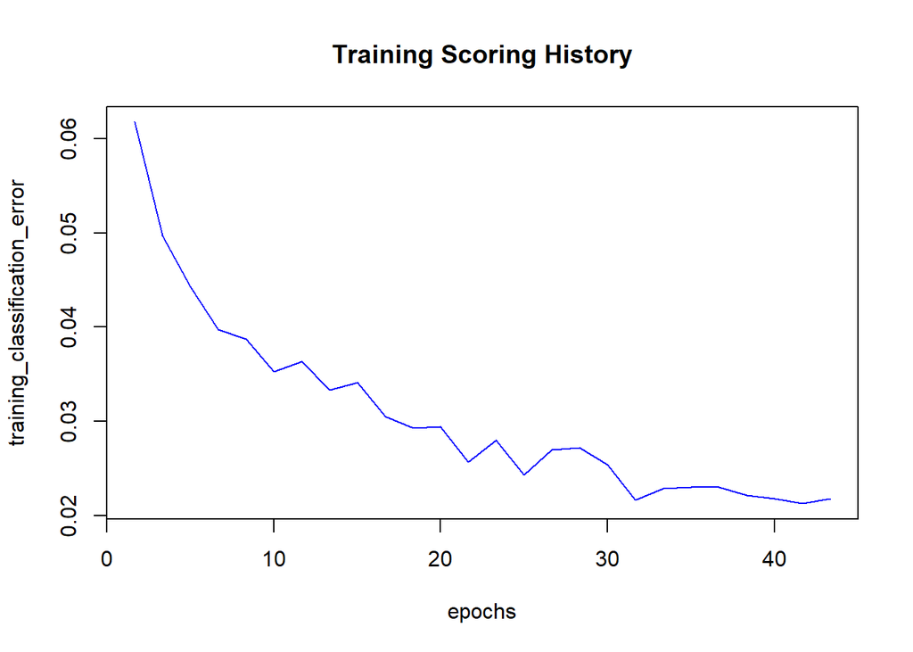

```r
# Wykres błędu klasyfikacji dla modelu 3
plot(dl_fit3_new,
     timestep = "epochs",
     metric = "classification_error")
```

Wykres przedstawia **błąd klasyfikacji** modelu w kroswalidacji w zależności od liczby epok. Oś X to liczba **epok treningowych**, a oś Y to **błąd klasyfikacji** modelu.

- **Niebieska linia (Training)**: Przedstawia błąd klasyfikacji na zbiorze treningowym w każdej epoce.
- **Pomarańczowa linia (Validation)**: Przedstawia błąd klasyfikacji na zbiorze walidacyjnym w każdej epoce.

### Interpretacja:

- **Błąd klasyfikacji na zbiorze treningowym** (niebieska linia) **maleje** z każdą epoką, co wskazuje, że model stopniowo poprawia swoje prognozy.
- **Błąd klasyfikacji na zbiorze walidacyjnym** (pomarańczowa linia) również maleje, ale w pewnym momencie może zacząć się **stabilizować** lub **wzrastać**, co może wskazywać na **przeuczenie modelu (overfitting)**. Model zaczyna się dobrze dopasowywać do danych treningowych, ale nie generalizuje dobrze na danych walidacyjnych.

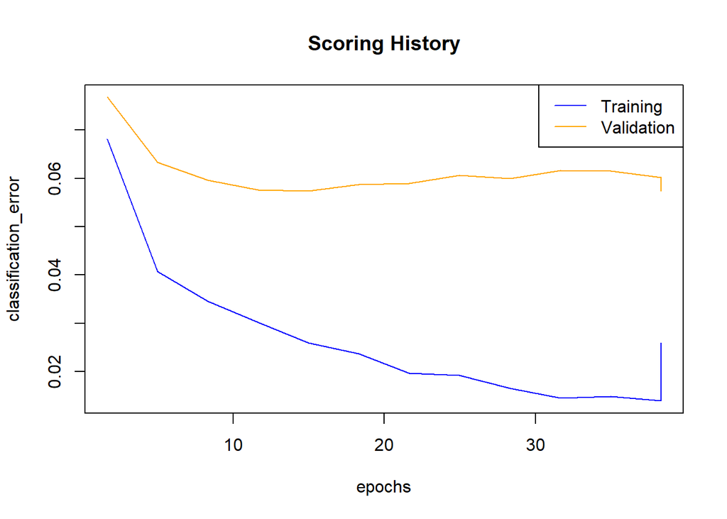

```r
# Pobieramy modele z kroswalidacji dla modelu 3
cv_models_new <- sapply(dl_fit3_new@model$cross_validation_models,
                        function(i) h2o.getModel(i$name))

# Wykres historii wyników dla pierwszego modelu w kroswalidacji
plot(cv_models_new[[1]],
     timestep = "epochs",
     metric = "classification_error")
```

## tutaj co się zmienia

**Definicja hiperparametrów dla modelu**: - **`activation_opt_new`**: Określenie dostępnych funkcji aktywacji, które będą używane w modelu (np. `Rectifier`, `Maxout`, `Tanh`). - **`l1_opt_new`** i **`l2_opt_new`**: Określają zakres wartości dla współczynników regularizacji L1 i L2, które są stosowane w modelu, aby zapobiegać przeuczeniu. - **`hyper_params_new`**: Tworzy listę z określonymi hiperparametrami, które będą używane podczas trenowania modelu, w tym funkcje aktywacji i współczynniki regularizacji.

```r
# Definiujemy hiperparametry do wyszukiwania
activation_opt_new <- c("Rectifier", "Maxout", "Tanh")
l1_opt_new <- c(0, 0.00001, 0.0001, 0.001, 0.01)
l2_opt_new <- c(0, 0.00001, 0.0001, 0.001, 0.01)

hyper_params_new <- list(activation = activation_opt_new, l1 = l1_opt_new, l2 = l2_opt_new)
search_criteria_new <- list(strategy = "RandomDiscrete", max_runtime_secs = 600)
```

**Podział danych na zestaw treningowy i walidacyjny**: - **`h2o.splitFrame()`**: Dzieli dane (zbiór `train_new`) na dwie części: zestaw treningowy (80% danych) i walidacyjny (20% danych). Jest to kluczowy krok w uczeniu maszynowym, aby ocenić wydajność modelu na nowych, niewidzianych danych.

```r
# Dzielimy dane na zestaw treningowy i walidacyjny
splits_new <- h2o.splitFrame(train_new, ratios = 0.8, seed = 1)
```

### Tworzenie siatki hiperparametrów dla modelu głębokiego uczenia

Funkcja **`h2o.grid()`** tworzy siatkę hiperparametrów, która testuje różne kombinacje ustawień modelu w celu znalezienia najlepszych parametrów.

- **`x`** i **`y`**: Zmienna **`x`** to cechy, a **`y`** to zmienna celu, którą model będzie przewidywał.
- **`grid_id`**: Określa unikalny identyfikator dla siatki hiperparametrów.
- **`training_frame`** i **`validation_frame`**: Zbiory danych treningowych i walidacyjnych, na których model będzie trenowany i testowany.
- **`hidden`**: Liczba warstw ukrytych w sieci neuronowej (w tym przypadku 2 warstwy po 20 neuronów).
- **`hyper_params`**: Lista hiperparametrów, takich jak funkcje aktywacji, współczynniki regularizacji.
- **`search_criteria`**: Kryteria przeszukiwania przestrzeni hiperparametrów, np. metoda losowa.

```r
# Tworzymy siatkę hiperparametrów dla głębokiego uczenia
dl_grid_new <- h2o.grid("deeplearning", x = x_new, y = y_new,
                        grid_id = "dl_grid_new",
                        training_frame = splits_new[[1]],
                        validation_frame = splits_new[[2]],
                        seed = 1,
                        hidden = c(20, 20),
                        hyper_params = hyper_params_new,
                        search_criteria = search_criteria_new)
```

```
##   |                                                                              |                                                                      |   0%  |                                                                              |=                                                        …
```

Pobieramy wyniki z **grid search** i sortujemy je według dokładności (accuracy) modelu, aby uzyskać najlepsze wyniki.

```r
# Sprawdzamy wyniki grid search dla najlepszych modeli
dl_gridperf_new <- h2o.getGrid(grid_id = "dl_grid_new",
                               sort_by = "accuracy",
                               decreasing = TRUE)
print(dl_gridperf_new)
```

```
## H2O Grid Details
## ================
##
## Grid ID: dl_grid_new
## Used hyper parameters:
##   -  activation
##   -  l1
##   -  l2
## Number of models: 59
## Number of failed models: 0
##
## Hyper-Parameter Search Summary: ordered by decreasing accuracy
##   activation      l1      l2            model_ids accuracy
## 1     Maxout 0.00010 0.01000 dl_grid_new_model_49  0.96482
## 2     Maxout 0.00010 0.00100 dl_grid_new_model_17  0.96465
## 3     Maxout 0.00100 0.00000 dl_grid_new_model_23  0.96457
## 4     Maxout 0.00001 0.00100 dl_grid_new_model_16  0.96348
## 5     Maxout 0.00000 0.00100  dl_grid_new_model_9  0.96273
##
## ---
##    activation      l1      l2            model_ids accuracy
## 54  Rectifier 0.01000 0.00010 dl_grid_new_model_35  0.90579
## 55  Rectifier 0.01000 0.00000 dl_grid_new_model_26  0.90203
## 56  Rectifier 0.01000 0.01000 dl_grid_new_model_50  0.89411
## 57       Tanh 0.01000 0.00001 dl_grid_new_model_52  0.88403
## 58       Tanh 0.01000 0.00010 dl_grid_new_model_20  0.87686
## 59       Tanh 0.01000 0.00100 dl_grid_new_model_15  0.87077
```

```r
# Pobieramy najlepszy model z siatki
best_dl_model_id_new <- dl_gridperf_new@model_ids[[1]]
best_dl_new <- h2o.getModel(best_dl_model_id_new)
```

```r
# Oceniamy najlepszy model na zestawie testowym
best_dl_perf_new <- h2o.performance(model = best_dl_new, newdata = test_new)
h2o.mse(best_dl_perf_new)
```

```
## [1] 0.03553165
```

### Generalized Linear Model (GLM)

Generalized Linear Model (GLM) to uogólnienie klasycznego modelu regresji liniowej, które pozwala modelować zależność między zmienną objaśnianą a zmiennymi objaśniającymi przy założeniu, że zmienna zależna pochodzi z rozkładu z rodziny wykładniczej (np. normalny, Poissona, Bernoulliego). Model GLM składa się z trzech elementów: funkcji łączącej (łączącej wartość oczekiwaną zmiennej zależnej z kombinacją liniową predyktorów), rozkładu prawdopodobieństwa oraz funkcji wariancji.

```r
data_file <- "./data/loan.csv"
if (!file.exists(data_file)) {
  data_file <- "https://raw.githubusercontent.com/ledell/LatinR-2019-h2o-tutorial/master/data/loan.csv"
}
data <- h2o.importFile(data_file)
```

```
##   |                                                                              |                                                                      |   0%  |                                                                              |=====                                                    …
```

```r
dim(data)
```

```
## [1] 163987     15
```

```r
nrows_subset <- 30000
data <- data[1:nrows_subset, ]
```

```r
data$bad_loan <- as.factor(data$bad_loan)
h2o.levels(data$bad_loan)
```

```
## [1] "0" "1"
```

```r
h2o.describe(data)
```

```
##                    Label Type Missing Zeros PosInf NegInf     Min       Max
## 1              loan_amnt  int       0     0      0      0 1000.00 3.500e+04
## 2                   term enum       0 22805      0      0    0.00 1.000e+00
## 3               int_rate real       0     0      0      0    5.42 2.440e+01
## 4             emp_length  int     972  3149      0      0    0.00 1.000e+01
## 5         home_ownership enum       0     0      0      0    1.00 5.000e+00
## 6             annual_inc real       0     0      0      0 4080.00 6.000e+06
## 7                purpose enum       0  1154      0      0    0.00 1.300e+01
## 8             addr_state enum       0    62      0      0    0.00 4.900e+01
## 9                    dti real       0   109      0      0    0.00 2.999e+01
## 10           delinq_2yrs  int       0 26755      0      0    0.00 1.100e+01
## 11            revol_util real      28   721      0      0    0.00 9.990e+01
## 12             total_acc  int       0     0      0      0    3.00 9.000e+01
## 13              bad_loan enum       0 25418      0      0    0.00 1.000e+00
## 14 longest_credit_length  int       0     0      0      0    3.00 6.500e+01
```

[output cut: 17 more lines]

```r
splits <- h2o.splitFrame(data = data,
                         ratios = c(0.7, 0.15),  # partition data into 70%, 15%, 15% chunks
                         destination_frames = c("train", "valid", "test"), # frame ID (not required)
                         seed = 1)  # setting a seed will guarantee reproducibility
train <- splits[[1]]
valid <- splits[[2]]
test <- splits[[3]]

nrow(train)
```

```
## [1] 21101
```

```r
nrow(valid)
```

```
## [1] 4407
```

```r
nrow(test)
```

```
## [1] 4492
```

```r
y <- "bad_loan"
x <- setdiff(names(data), c(y, "int_rate"))
print(x)
```

```
##  [1] "loan_amnt"             "term"                  "emp_length"
##  [4] "home_ownership"        "annual_inc"            "purpose"
##  [7] "addr_state"            "dti"                   "delinq_2yrs"
## [10] "revol_util"            "total_acc"             "longest_credit_length"
## [13] "verification_status"
```

```r
glm_fit1 <- h2o.glm(x = x,
                    y = y,
                    training_frame = train,
                    family = "binomial")
```

```
##   |                                                                              |                                                                      |   0%  |                                                                              |=========================================================…
```

- Użycie funkcji h2o.glm() z pakietu H2O w R do stworzenia modelu GLM.
- training_frame = train — zbiór danych treningowych.
- family = “binomial” — model regresji logistycznej (klasyfikacja binarna).
- Domyślna funkcja linku to `logit`, typowa dla regresji logistycznej.

```r
glm_fit1@model$model_summary
```

```
## GLM Model: summary
##     family  link                                regularization
## 1 binomial logit Elastic Net (alpha = 0.5, lambda = 8.195E-5 )
##   number_of_predictors_total number_of_active_predictors number_of_iterations
## 1                         82                          54                    4
##   training_frame
## 1          train
```

- Elastic Net łączy regularizację L1 i L2 z parametrem `alpha = 0.5`, a `lambda = 8.195E-5` określa siłę kary za złożoność modelu.
- Model jest trenowany iteracyjnie, aż osiągnie optymalne dopasowanie.
- Do modelu podano 82 predyktory.
- Po regularizacji aktywnych zostało 54 predyktorów, co oznacza usunięcie mniej istotnych zmiennych.
- Model zakończył dopasowanie po 4 iteracjach, co wskazuje na szybkie zbieżenie.
- Uczenie odbywa się na zbiorze treningowym `train`.
- Regularizacja pomaga zapobiegać przeuczeniu, poprawiając zdolność modelu do generalizacji.

```r
head(h2o.coef(glm_fit1))
```

```
##     Intercept addr_state.AK addr_state.AL addr_state.AR addr_state.AZ
##    -1.5272685     0.0000000    -0.2781867     0.0000000    -0.1236904
## addr_state.CA
##     0.1655847
```

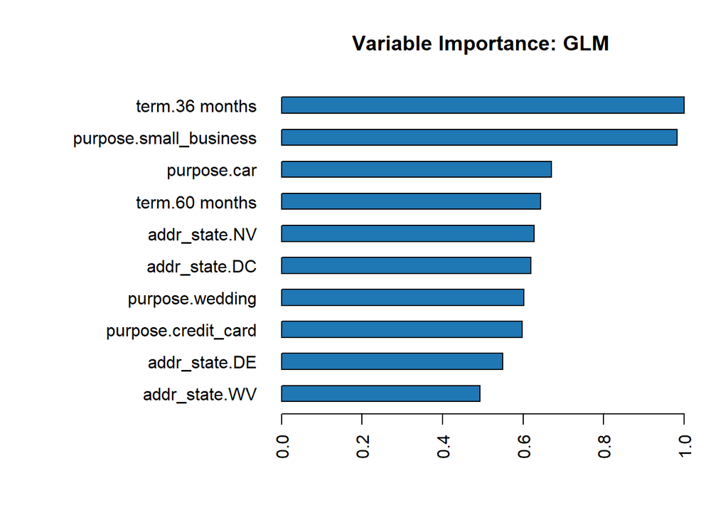

```r
h2o.varimp_plot(glm_fit1)
```

Najważniejsze zmienne w modelu to: długość okresu pożyczki (term.36 months, term.60 months), cel pożyczki (np. small_business, car, wedding, credit_card) oraz stan zamieszkania (addr_state.NV, addr_state.DC itd.). Te cechy mają największy wpływ na przewidywania modelu.

```r
glm_perf1 <- h2o.performance(model = glm_fit1,
                             newdata = test)
print(glm_perf1)
```

```
## H2OBinomialMetrics: glm
##
## MSE:  0.1240903
## RMSE:  0.3522645
## LogLoss:  0.4049784
## Mean Per-Class Error:  0.3360059
## AUC:  0.7145034
## AUCPR:  0.3491947
## Gini:  0.4290067
## R^2:  0.09423842
## Residual Deviance:  3638.326
## AIC:  3748.326
##
## Confusion Matrix (vertical: actual; across: predicted) for F1-optimal threshold:
##           0    1    Error        Rate
## 0      2916  840 0.223642   =840/3756
## 1       330  406 0.448370    =330/736
## Totals 3246 1246 0.260463  =1170/4492
##
## Maximum Metrics: Maximum metrics at their respective thresholds
##                         metric threshold       value idx
## 1                       max f1  0.170732    0.409687 210
## 2                       max f2  0.091286    0.539828 305
## 3                 max f0point5  0.295598    0.395284 124
## 4                 max accuracy  0.517959    0.839715  23
## 5                max precision  0.517959    0.690476  23
## 6                   max recall  0.010370    1.000000 396
## 7              max specificity  0.754570    0.999734   0
## 8             max absolute_mcc  0.170732    0.271161 210
## 9   max min_per_class_accuracy  0.132256    0.657609 251
## 10 max mean_per_class_accuracy  0.163826    0.665665 217
## 11                     max tns  0.754570 3755.000000   0
## 12                     max fns  0.754570  736.000000   0
## 13                     max fps  0.000230 3756.000000 399
## 14                     max tps  0.010370  736.000000 396
## 15                     max tnr  0.754570    0.999734   0
## 16                     max fnr  0.754570    1.000000   0
## 17                     max fpr  0.000230    1.000000 399
## 18                     max tpr  0.010370    1.000000 396
##
## Gains/Lift Table: Extract with `h2o.gainsLift(<model>, <data>)` or `h2o.gainsLift(<model>, valid=<T/F>, xval=<T/F>)`
```

## Interpretacja wyników modelu GLM z pakietu H2O

### Macierz konfuzji

- Model dobrze rozpoznaje klasę 0 (77.6% poprawnych przewidywań).
- Klasa 1 jest trudniejsza do klasyfikacji (44.87% błędów).
- Całkowity błąd klasyfikacji to 26%.

threshold - Wartość progu (threshold), przy którym osiągnięto podaną wartość metryki. W klasyfikacji to granica decydująca o przypisaniu klasy. value - Zmierzona wartość metryki przy danym progu, pokazująca jakość modelu według tej metryki. idx - Indeks lub identyfikator próbki/danych, przy którym osiągnięto tę wartość metryki.

### Podsumowanie

```r
h2o.auc(glm_perf1)
```

```
## [1] 0.7145034
```

```r
preds <- predict(glm_fit1, newdata = test)
```

```
##   |                                                                              |                                                                      |   0%  |                                                                              |=========================================================…
```

```r
head(preds)
```

```
##   predict        p0         p1
## 1       0 0.8726513 0.12734871
## 2       0 0.8307221 0.16927790
## 3       0 0.9262081 0.07379189
## 4       1 0.7130928 0.28690724
## 5       1 0.6322728 0.36772718
## 6       1 0.6791832 0.32081679
```

- **predict**: Przewidywana klasa (etykieta) dla danej obserwacji, wynikająca z modelu.
- **p0**: Prawdopodobieństwo, że obserwacja należy do klasy 0.
- **p1**: Prawdopodobieństwo, że obserwacja należy do klasy 1.

```r
glm_fit2 <- h2o.glm(x = x,
                    y = y,
                    training_frame = train,
                    family = "binomial",
                    nfolds = 5,
                    seed = 1)
```

```
##   |                                                                              |                                                                      |   0%  |                                                                              |=========================================================…
```

- nfolds: liczba podziałów danych w walidacji krzyżowej (cross-validation).  
  Dane treningowe są dzielone na *nfolds* części, a model jest trenowany i testowany *nfolds* razy, za każdym razem na innych podzbiorach.  
  Pozwala to na rzetelną ocenę jakości modelu i jego zdolności do generalizacji.

```r
h2o.auc(glm_fit2, xval = TRUE)
```

```
## [1] 0.7196308
```